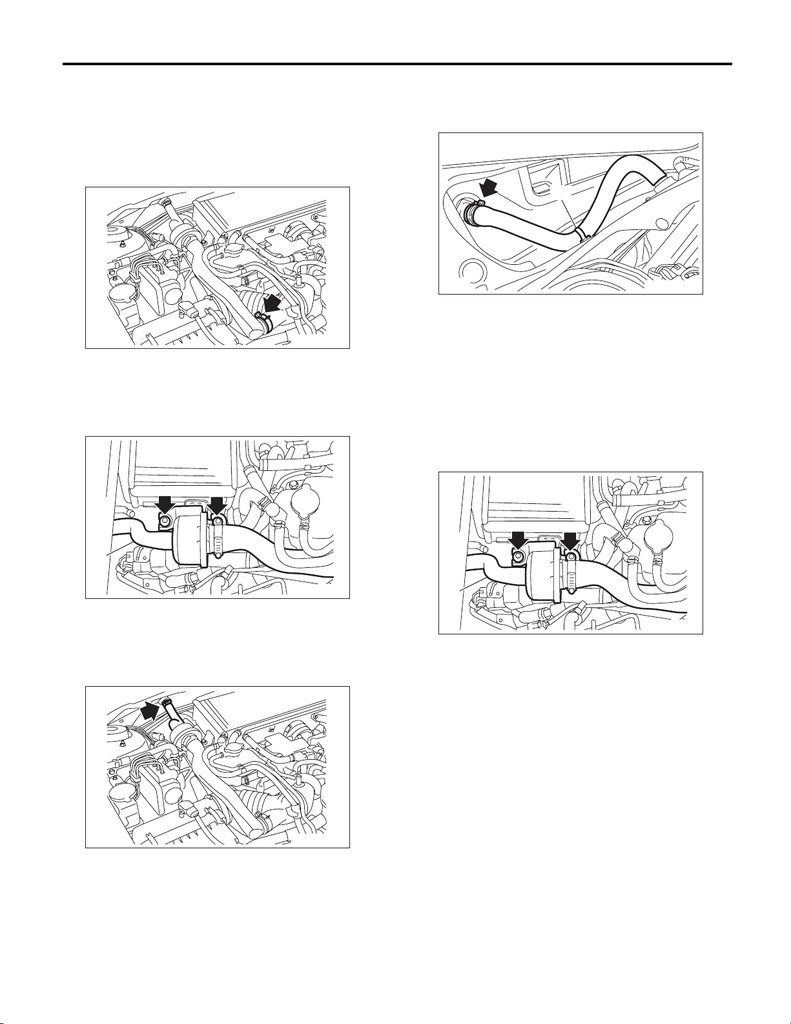

IN(STI)-22

Chamber Assembly

INTAKE (INDUCTION)

10.Chamber Assembly

A: REMOVAL

1. CHAMBER ASSEMBLY

1) Loosen the clip that secures the chamber as-

sembly.

2) Disconnect the hose (front) (A) from the cham-

ber assembly.

3) Remove the bolts which secure the chamber as-

sembly to the intercooler stay RH No. 1, and re-

move the chamber assembly.

2. HOSE

1) Disconnect the hose (front).

NOTE:

Be careful not to damage the grommet.

2) Remove the cowl panel. <Ref. to EI-45, RE-

MOVAL, Cowl Panel.>

3) Remove clip (A), and remove the hose (rear).

NOTE:

Be careful not to damage the grommet.

B: INSTALLATION

1. CHAMBER ASSEMBLY

1) Set the chamber assembly to the vehicle, and in-

stall the bolts securing the chamber assembly to

the intercooler stay RH No. 1.

Tightening torque:

6 N·m (0.6 kgf-m, 4.4 ft-lb)

2) Connect the hose (front) (A) to the chamber as-

sembly.

IN-03641

(A)

IN-03651

IN-03638

(A)

IN-03641

(A)

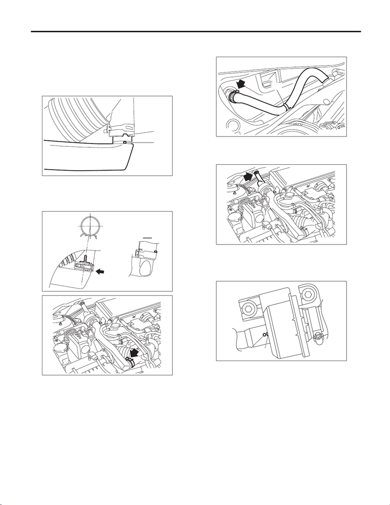

IN(STI)-23

Chamber Assembly

INTAKE (INDUCTION)

3) Install the clip that secures the chamber assem-

bly.

NOTE:

• Align the concave section (a) of the air intake

boot side to the positioning protrusion section (b) of

the chamber duct side, and insert until the end face

of chamber duct contacts the air intake boot.

• Align the center of the clip tab to the center of the

T-shaped protrusion of the chamber duct.

• Be careful so that the clip does not ride on the

protrusion at the bottom of the chamber duct.

2. HOSE

1) Connect the hose (rear) and install clip (A).

2) Install the cowl panel. <Ref. to EI-46, INSTAL-

LATION, Cowl Panel.>

3) Connect the hose (front).

NOTE:

Align the alignment mark (a) on the chamber as-

sembly to the alignment mark (b) on the hose

(front) to connect.

(a)

(b)

IN-03642

A

A

IN-03640

IN-03638

(A)

IN-03651

IN-03645

(a)

(b)

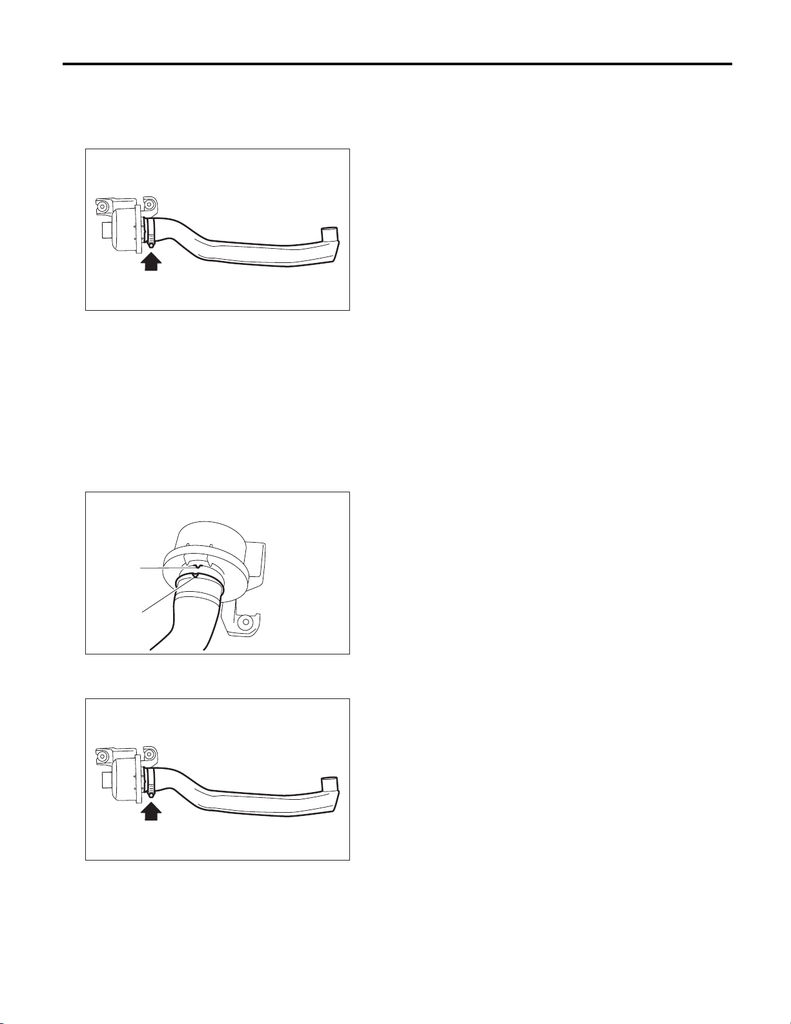

IN(STI)-24

Chamber Assembly

INTAKE (INDUCTION)

C: DISASSEMBLY

1) Loosen the clamp securing the chamber duct,

and remove the chamber duct from chamber as-

sembly.

D: ASSEMBLY

1) Install the chamber duct to the chamber assem-

bly, and tighten the clamp which holds the chamber

assembly and chamber duct.

NOTE:

Align the positioning protrusion section (a) of the

chamber assembly to the concave section (b) of

the chamber duct side, and securely insert until the

end face of chamber duct contacts the chamber as-

sembly.

Tightening torque:

2.5 N·m (0.3 kgf-m, 1.8 ft-lb)

IN-03575

(a)

(b)

IN-03643

[figure not shown]

MECHANICAL

ME(STI)

Page

2. Compression ............................................................................................20

3. Idle Speed ................................................................................................21

4. Ignition Timing ..........................................................................................22

5. Intake Manifold Vacuum ...........................................................................23

6. Engine Oil Pressure .................................................................................24

7. Fuel Pressure ...........................................................................................25

8. Valve Clearance .......................................................................................26

9. Engine Assembly .....................................................................................30

10. Engine Mounting ......................................................................................39

11. Preparation for Overhaul ..........................................................................40

12. V-belt ........................................................................................................41

13. Crank Pulley .............................................................................................48

14. Timing Belt Cover .....................................................................................50

15. Timing Belt ...............................................................................................51

16. Cam Sprocket ..........................................................................................60

17. Crank Sprocket ........................................................................................61

18. Camshaft ..................................................................................................62

19. Cylinder Head ..........................................................................................70

20. Cylinder Block ..........................................................................................80

21. Intake and Exhaust Valve ......................................................................103

22. Piston .....................................................................................................104

23. Connecting Rod .....................................................................................105

24. Crankshaft ..............................................................................................106

25. Engine Trouble in General .....................................................................107

26. Engine Noise ..........................................................................................113